# Three perspectives on integration

Daniel Kaplan

The equation below shows three items, all of which are equivalent even though they look different. You can see this from the equal signs separating the three items.

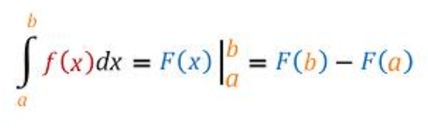

When you reach the point where you can say, “That’s obvious,” and can write down the three items from memory, you will have achieved an important facility with calculus.

**Question tmp-1**: Since the three items are equivalent, they are all the same kind of “thing.” What kind of thing are they?

1. a number (($\surd$) ) [Another term for this is *definite integral*. Evaluating an anti-derivative at two values of $x$ and subtracting one from the other gives a number. (Remember, in our notation, $a$ and $b$ stand for numerical constants, unless we specifically say otherwise.)]
2. a function of $x$ [Each of the items include something that is a function of $x$, but the entire item is not itself a function of $x$.]
3. an interval [Each of the items includes an interval, but the entire item is not one.]
4. a limit of integration [Each of the items includes a limit of integration, but the entire item is not one.]
5. an anti-derivative [There is an anti-derivative involved in each item, but the entire item is not one.]
6. a constant of integration [No constant of integration is needed to express any of the items]

The equation has been [written in color](https://betterexplained.com/articles/colorized-math-equations/) to help you identify elements that are the same in each of the three items.

**Question tmp-2**: Which of the colors stands for *a limit of integration*?

1. black []
2. blue []
3. tan (($\surd$) ) []
4. red []

**Question tmp-3**: Which of the colors stands for *the derivative of a function that appears elsewhere in the equation*?

1. black []
2. blue []
3. tan []
4. red (($\surd$) ) []

**Question tmp-4**: Which of the colors stands for *an anti-derivative of a function that appears elsewhere in the equation*?

1. black []
2. blue (($\surd$) ) []
3. tan []
4. red []